# Cyclistic Bike Share Case Study

Kengne Romaric

2025-12-11

### Google Data Analytics Capstone project

## I.Context

Cyclistic, is a bike-share company in Chicago.

The director of marketing believes the company’s future success depends on maximizing the number of annual memberships.

Therefore, our team wants to understand how casual riders and annual members use Cyclistic bikes differently.

As a junior data analyst working on the marketing analyst team at Cyclistic, I was tasked to analyze the Cyclistic historical bike trip data to identify trends.

From these insights, our team will design a new marketing strategy to convert casual riders into annual members.

NB:

*Customers who purchase single-ride or full-day passes are referred to as casual riders.

*Customers who purchase annual memberships are Cyclistic members.

## II.Task

How differently do casual riders and annual members use cyclistic bikes?

**Stakeholder:**

*Director of marketing/Manager

*The marketing analytics team

*The executive team

## III.Data source

**Source:** https://divvy-tripdata.s3.amazonaws.com/index.html

Data provided by Motivate International Inc.

Our data set is constituted of rides from the Past 12 months on 08/12/2025.

The data is constituted of rides from 11/2024 to 10/2025.

## IV.Preparation of the dataset

All 12 months datasets were downloaded locally from the source cited above and analyzed using RStudio using R 4.5.2

We began our analysis by loading the Tidyverse package

```r
library(tidyverse)
```

We set our local file as working directory

```r
#Setting our local file containing the datasets as local directory
setwd("E:/DOCUMENTS ROMARIC/Data analytics/Google data analytics certification/Resources/Course 8/Case study 1/divvy trip data")
```

We imported all data sets into RStudio

```r
#Importing all 12 datasets into RStudio
x202411 <- read.csv("202411-divvy-tripdata.csv")
x202412 <- read.csv("202412-divvy-tripdata.csv")
x202501 <- read.csv("202501-divvy-tripdata.csv")
x202502 <- read.csv("202502-divvy-tripdata.csv")
x202503 <- read.csv("202503-divvy-tripdata.csv")
x202504 <- read.csv("202504-divvy-tripdata.csv")
x202505 <- read.csv("202505-divvy-tripdata.csv")
x202506 <- read.csv("202506-divvy-tripdata.csv")
x202507 <- read.csv("202507-divvy-tripdata.csv")
x202508 <- read.csv("202508-divvy-tripdata.csv")
x202509 <- read.csv("202509-divvy-tripdata.csv")
x202510 <- read.csv("202510-divvy-tripdata.csv")
```

We merged all the datasets into one.

But before,

We checked all columns within the datasets

```r
#Comparing column names
colnames(x202411)
```

```
##  [1] "ride_id"            "rideable_type"      "started_at"
##  [4] "ended_at"           "start_station_name" "start_station_id"
##  [7] "end_station_name"   "end_station_id"     "start_lat"
## [10] "start_lng"          "end_lat"            "end_lng"
## [13] "member_casual"
```

```r
colnames(x202412)
```

```
##  [1] "ride_id"            "rideable_type"      "started_at"
##  [4] "ended_at"           "start_station_name" "start_station_id"
##  [7] "end_station_name"   "end_station_id"     "start_lat"
## [10] "start_lng"          "end_lat"            "end_lng"
## [13] "member_casual"
```

```r
colnames(x202501)
```

```
##  [1] "ride_id"            "rideable_type"      "started_at"
##  [4] "ended_at"           "start_station_name" "start_station_id"
##  [7] "end_station_name"   "end_station_id"     "start_lat"
## [10] "start_lng"          "end_lat"            "end_lng"
## [13] "member_casual"
```

```r
colnames(x202502)
```

```
##  [1] "ride_id"            "rideable_type"      "started_at"
##  [4] "ended_at"           "start_station_name" "start_station_id"
##  [7] "end_station_name"   "end_station_id"     "start_lat"
## [10] "start_lng"          "end_lat"            "end_lng"
## [13] "member_casual"
```

```r
colnames(x202503)
```

```
##  [1] "ride_id"            "rideable_type"      "started_at"
##  [4] "ended_at"           "start_station_name" "start_station_id"
##  [7] "end_station_name"   "end_station_id"     "start_lat"
## [10] "start_lng"          "end_lat"            "end_lng"
## [13] "member_casual"
```

```r
colnames(x202504)
```

```
##  [1] "ride_id"            "rideable_type"      "started_at"
##  [4] "ended_at"           "start_station_name" "start_station_id"
##  [7] "end_station_name"   "end_station_id"     "start_lat"
## [10] "start_lng"          "end_lat"            "end_lng"
## [13] "member_casual"
```

```r
colnames(x202505)
```

```
##  [1] "ride_id"            "rideable_type"      "started_at"
##  [4] "ended_at"           "start_station_name" "start_station_id"
##  [7] "end_station_name"   "end_station_id"     "start_lat"
## [10] "start_lng"          "end_lat"            "end_lng"
## [13] "member_casual"
```

```r
colnames(x202506)
```

```
##  [1] "ride_id"            "rideable_type"      "started_at"
##  [4] "ended_at"           "start_station_name" "start_station_id"
##  [7] "end_station_name"   "end_station_id"     "start_lat"
## [10] "start_lng"          "end_lat"            "end_lng"
## [13] "member_casual"
```

```r
colnames(x202507)
```

```
##  [1] "ride_id"            "rideable_type"      "started_at"
##  [4] "ended_at"           "start_station_name" "start_station_id"
##  [7] "end_station_name"   "end_station_id"     "start_lat"
## [10] "start_lng"          "end_lat"            "end_lng"
## [13] "member_casual"
```

```r
colnames(x202508)
```

```
##  [1] "ride_id"            "rideable_type"      "started_at"
##  [4] "ended_at"           "start_station_name" "start_station_id"
##  [7] "end_station_name"   "end_station_id"     "start_lat"
## [10] "start_lng"          "end_lat"            "end_lng"
## [13] "member_casual"
```

```r
colnames(x202509)
```

```
##  [1] "ride_id"            "rideable_type"      "started_at"
##  [4] "ended_at"           "start_station_name" "start_station_id"
##  [7] "end_station_name"   "end_station_id"     "start_lat"
## [10] "start_lng"          "end_lat"            "end_lng"
## [13] "member_casual"
```

```r
colnames(x202510)
```

```
##  [1] "ride_id"            "rideable_type"      "started_at"
##  [4] "ended_at"           "start_station_name" "start_station_id"
##  [7] "end_station_name"   "end_station_id"     "start_lat"
## [10] "start_lng"          "end_lat"            "end_lng"
## [13] "member_casual"
```

We then checked each column data type

```r
str(x202411)
```

```
## 'data.frame':    335075 obs. of  13 variables:
##  $ ride_id           : chr  "578DDD7CE1771FFA" "78B141C50102ABA6" "1E794CF36394E2D7" "E5DD2CAB58D73F98" ...
##  $ rideable_type     : chr  "classic_bike" "classic_bike" "classic_bike" "classic_bike" ...
##  $ started_at        : chr  "2024-11-07 19:21:58.206" "2024-11-22 14:49:00.431" "2024-11-08 09:24:00.238" "2024-11-24 17:51:14.144" ...
##  $ ended_at          : chr  "2024-11-07 19:28:57.301" "2024-11-22 14:56:15.475" "2024-11-08 09:28:33.480" "2024-11-24 18:05:32.574" ...
##  $ start_station_name: chr  "Walsh Park" "Walsh Park" "Walsh Park" "Clark St & Elm St" ...
##  $ start_station_id  : chr  "18067" "18067" "18067" "TA1307000039" ...
##  $ end_station_name  : chr  "Leavitt St & North Ave" "Leavitt St & Armitage Ave" "Damen Ave & Cortland St" "Clark St & Drummond Pl" ...
##  $ end_station_id    : chr  "TA1308000005" "TA1309000029" "13133" "TA1307000142" ...
##  $ start_lat         : num  41.9 41.9 41.9 41.9 41.9 ...
##  $ start_lng         : num  -87.7 -87.7 -87.7 -87.6 -87.6 ...
##  $ end_lat           : num  41.9 41.9 41.9 41.9 41.9 ...
##  $ end_lng           : num  -87.7 -87.7 -87.7 -87.6 -87.6 ...
##  $ member_casual     : chr  "member" "member" "member" "member" ...
```

```r
str(x202412)
```

```
## 'data.frame':    178372 obs. of  13 variables:
##  $ ride_id           : chr  "6C960DEB4F78854E" "C0913EEB2834E7A2" "848A37DD4723078A" "3FA09C762ECB48BD" ...
##  $ rideable_type     : chr  "electric_bike" "classic_bike" "classic_bike" "electric_bike" ...
##  $ started_at        : chr  "2024-12-31 01:38:35.018" "2024-12-21 18:41:26.478" "2024-12-21 11:41:01.664" "2024-12-26 13:07:27.526" ...
##  $ ended_at          : chr  "2024-12-31 01:48:45.775" "2024-12-21 18:47:33.871" "2024-12-21 11:52:45.094" "2024-12-26 13:10:54.130" ...
##  $ start_station_name: chr  "Halsted St & Roscoe St" "Clark St & Wellington Ave" "Sheridan Rd & Montrose Ave" "Aberdeen St & Jackson Blvd" ...
##  $ start_station_id  : chr  "TA1309000025" "TA1307000136" "TA1307000107" "13157" ...
##  $ end_station_name  : chr  "Clark St & Winnemac Ave" "Halsted St & Roscoe St" "Broadway & Barry Ave" "Green St & Randolph St*" ...
##  $ end_station_id    : chr  "TA1309000035" "TA1309000025" "13137" "chargingstx3" ...
##  $ start_lat         : num  41.9 41.9 42 41.9 41.9 ...
##  $ start_lng         : num  -87.6 -87.6 -87.7 -87.7 -87.7 ...
##  $ end_lat           : num  42 41.9 41.9 41.9 41.9 ...
##  $ end_lng           : num  -87.7 -87.6 -87.6 -87.6 -87.7 ...
##  $ member_casual     : chr  "member" "member" "member" "member" ...
```

```r
str(x202501)
```

```
## 'data.frame':    138689 obs. of  13 variables:
##  $ ride_id           : chr  "7569BC890583FCD7" "013609308856B7FC" "EACACD3CE0607C0D" "EAA2485BA64710D3" ...
##  $ rideable_type     : chr  "classic_bike" "electric_bike" "classic_bike" "classic_bike" ...
##  $ started_at        : chr  "2025-01-21 17:23:54.538" "2025-01-11 15:44:06.795" "2025-01-02 15:16:27.730" "2025-01-23 08:49:05.814" ...
##  $ ended_at          : chr  "2025-01-21 17:37:52.015" "2025-01-11 15:49:11.139" "2025-01-02 15:28:03.230" "2025-01-23 08:52:40.047" ...
##  $ start_station_name: chr  "Wacker Dr & Washington St" "Halsted St & Wrightwood Ave" "Southport Ave & Waveland Ave" "Southport Ave & Waveland Ave" ...
##  $ start_station_id  : chr  "KA1503000072" "TA1309000061" "13235" "13235" ...
##  $ end_station_name  : chr  "McClurg Ct & Ohio St" "Racine Ave & Belmont Ave" "Broadway & Cornelia Ave" "Southport Ave & Roscoe St" ...
##  $ end_station_id    : chr  "TA1306000029" "TA1308000019" "13278" "13071" ...
##  $ start_lat         : num  41.9 41.9 41.9 41.9 41.9 ...
##  $ start_lng         : num  -87.6 -87.6 -87.7 -87.7 -87.7 ...
##  $ end_lat           : num  41.9 41.9 41.9 41.9 41.9 ...
##  $ end_lng           : num  -87.6 -87.7 -87.6 -87.7 -87.7 ...
##  $ member_casual     : chr  "member" "member" "member" "member" ...
```

```r
str(x202502)
```

```
## 'data.frame':    151880 obs. of  13 variables:
##  $ ride_id           : chr  "A246CA24873F7C5C" "303C0906F3F068AE" "A0F65F3531F1FB2B" "CE663C815B6A6D73" ...
##  $ rideable_type     : chr  "classic_bike" "classic_bike" "electric_bike" "electric_bike" ...
##  $ started_at        : chr  "2025-02-25 21:21:21.171" "2025-02-08 14:55:13.493" "2025-02-24 00:32:56.553" "2025-02-07 17:00:38.646" ...
##  $ ended_at          : chr  "2025-02-25 21:30:09.941" "2025-02-08 15:13:39.890" "2025-02-24 00:38:21.711" "2025-02-07 17:34:29.012" ...
##  $ start_station_name: chr  "Michigan Ave & Lake St" "Ogden Ave & Race Ave" "Michigan Ave & Lake St" "Ogden Ave & Race Ave" ...
##  $ start_station_id  : chr  "TA1305000011" "13194" "TA1305000011" "13194" ...
##  $ end_station_name  : chr  "Clark St & Elm St" "Clark St & Elm St" "Wabash Ave & 9th St" "Clark St & Elm St" ...
##  $ end_station_id    : chr  "TA1307000039" "TA1307000039" "TA1309000010" "TA1307000039" ...
##  $ start_lat         : num  41.9 41.9 41.9 41.9 41.9 ...
##  $ start_lng         : num  -87.6 -87.7 -87.6 -87.7 -87.6 ...
##  $ end_lat           : num  41.9 41.9 41.9 41.9 41.9 ...
##  $ end_lng           : num  -87.6 -87.6 -87.6 -87.6 -87.6 ...
##  $ member_casual     : chr  "member" "member" "casual" "casual" ...
```

```r
str(x202503)
```

```
## 'data.frame':    298155 obs. of  13 variables:
##  $ ride_id           : chr  "16CBE9844D401954" "1CB408029E2B5F74" "7B6A76CD0F204D08" "4F7084E3D75CDE31" ...
##  $ rideable_type     : chr  "electric_bike" "electric_bike" "electric_bike" "electric_bike" ...
##  $ started_at        : chr  "2025-03-18 08:39:20.065" "2025-03-24 16:04:22.239" "2025-03-10 16:06:19.708" "2025-03-21 14:28:14.579" ...
##  $ ended_at          : chr  "2025-03-18 08:51:37.633" "2025-03-24 16:27:41.347" "2025-03-10 16:29:17.457" "2025-03-21 14:35:06.160" ...
##  $ start_station_name: chr  "" "" "" "" ...
##  $ start_station_id  : chr  "" "" "" "" ...
##  $ end_station_name  : chr  "Canal St & Jackson Blvd" "Albany Ave & Bloomingdale Ave" "Albany Ave & Bloomingdale Ave" "Canal St & Jackson Blvd" ...
##  $ end_station_id    : chr  "13138" "15655" "15655" "13138" ...
##  $ start_lat         : num  41.9 41.9 41.9 41.9 41.9 ...
##  $ start_lng         : num  -87.7 -87.7 -87.7 -87.6 -87.7 ...
##  $ end_lat           : num  41.9 41.9 41.9 41.9 41.9 ...
##  $ end_lng           : num  -87.6 -87.7 -87.7 -87.6 -87.7 ...
##  $ member_casual     : chr  "member" "member" "member" "member" ...
```

```r
str(x202504)
```

```
## 'data.frame':    371341 obs. of  13 variables:
##  $ ride_id           : chr  "AF3863596DF9D94B" "8B38081EBE918800" "1C7F1DE826BBBC8D" "CAD23D69A79A6C3B" ...
##  $ rideable_type     : chr  "classic_bike" "electric_bike" "electric_bike" "classic_bike" ...
##  $ started_at        : chr  "2025-04-27 14:29:34.619" "2025-04-23 17:48:51.863" "2025-04-05 17:55:30.845" "2025-04-03 08:22:04.493" ...
##  $ ended_at          : chr  "2025-04-27 14:36:23.584" "2025-04-23 17:59:06.015" "2025-04-05 18:05:40.032" "2025-04-03 08:32:06.099" ...
##  $ start_station_name: chr  "Troy St & Elston Ave" "Wabash Ave & Adams St" "Damen Ave & Cortland St" "Clark St & Elm St" ...
##  $ start_station_id  : chr  "15631" "KA1503000015" "13133" "TA1307000039" ...
##  $ end_station_name  : chr  "Richmond St & Diversey Ave" "Green St & Madison St" "California Ave & Fletcher St" "Orleans St & Merchandise Mart Plaza" ...
##  $ end_station_id    : chr  "15645" "TA1307000120" "15642" "TA1305000022" ...
##  $ start_lat         : num  41.9 41.9 41.9 41.9 41.9 ...
##  $ start_lng         : num  -87.7 -87.6 -87.7 -87.6 -87.7 ...
##  $ end_lat           : num  41.9 41.9 41.9 41.9 41.9 ...
##  $ end_lng           : num  -87.7 -87.6 -87.7 -87.6 -87.7 ...
##  $ member_casual     : chr  "member" "member" "member" "member" ...
```

```r
str(x202505)
```

```
## 'data.frame':    502456 obs. of  13 variables:
##  $ ride_id           : chr  "BADF67E2C5058F19" "0210AE485D59C8C5" "5E68FE5B9283E4C4" "13D2DCD6FB872858" ...
##  $ rideable_type     : chr  "classic_bike" "electric_bike" "classic_bike" "classic_bike" ...
##  $ started_at        : chr  "2025-05-11 17:22:39.471" "2025-05-05 08:02:09.251" "2025-05-02 10:32:33.062" "2025-05-12 11:12:16.579" ...
##  $ ended_at          : chr  "2025-05-11 18:11:19.249" "2025-05-05 08:12:07.549" "2025-05-02 10:39:07.262" "2025-05-12 11:17:25.126" ...
##  $ start_station_name: chr  "DuSable Lake Shore Dr & North Blvd" "Damen Ave & Grand Ave" "LaSalle St & Illinois St" "Milwaukee Ave & Rockwell St" ...
##  $ start_station_id  : chr  "LF-005" "TA1308000006" "13430" "13242" ...
##  $ end_station_name  : chr  "Winthrop Ave & Lawrence Ave" "Desplaines St & Jackson Blvd" "Clark St & Elm St" "Damen Ave & Cortland St" ...
##  $ end_station_id    : chr  "TA1308000021" "15539" "TA1307000039" "13133" ...
##  $ start_lat         : num  41.9 41.9 41.9 41.9 41.9 ...
##  $ start_lng         : num  -87.6 -87.7 -87.6 -87.7 -87.6 ...
##  $ end_lat           : num  42 41.9 41.9 41.9 41.9 ...
##  $ end_lng           : num  -87.7 -87.6 -87.6 -87.7 -87.6 ...
##  $ member_casual     : chr  "member" "member" "member" "member" ...
```

```r
str(x202506)
```

```
## 'data.frame':    678904 obs. of  13 variables:
##  $ ride_id           : chr  "0E43949BF937C7DA" "1CDEA40FEAF21789" "7ECEB1638575575C" "F275084E25F5A131" ...
##  $ rideable_type     : chr  "electric_bike" "classic_bike" "classic_bike" "electric_bike" ...
##  $ started_at        : chr  "2025-06-05 21:24:56.104" "2025-06-14 13:03:34.478" "2025-06-09 13:30:22.540" "2025-06-15 12:48:13.321" ...
##  $ ended_at          : chr  "2025-06-05 21:38:44.446" "2025-06-14 13:13:19.791" "2025-06-09 13:39:53.640" "2025-06-15 13:00:18.798" ...
##  $ start_station_name: chr  "Clark St & Armitage Ave" "Dearborn Pkwy & Delaware Pl" "Dearborn Pkwy & Delaware Pl" "Clark St & Elm St" ...
##  $ start_station_id  : chr  "CHI00474" "CHI00306" "CHI00306" "CHI00281" ...
##  $ end_station_name  : chr  "Dearborn Pkwy & Delaware Pl" "Kingsbury St & Kinzie St" "Kingsbury St & Kinzie St" "" ...
##  $ end_station_id    : chr  "CHI00306" "CHI00299" "CHI00299" "" ...
##  $ start_lat         : num  41.9 41.9 41.9 41.9 41.9 ...
##  $ start_lng         : num  -87.6 -87.6 -87.6 -87.6 -87.7 ...
##  $ end_lat           : num  41.9 41.9 41.9 41.9 41.9 ...
##  $ end_lng           : num  -87.6 -87.6 -87.6 -87.7 -87.7 ...
##  $ member_casual     : chr  "member" "member" "member" "member" ...
```

```r
str(x202507)
```

```
## 'data.frame':    763432 obs. of  13 variables:
##  $ ride_id           : chr  "455D43BD91D73437" "9D4A6B723ECD98CA" "C57044CF523302ED" "AFD35552E6685B6E" ...
##  $ rideable_type     : chr  "classic_bike" "classic_bike" "classic_bike" "electric_bike" ...
##  $ started_at        : chr  "2025-07-05 17:15:08.456" "2025-07-01 13:57:38.878" "2025-07-31 16:49:28.142" "2025-07-17 09:36:21.058" ...
##  $ ended_at          : chr  "2025-07-05 17:25:47.079" "2025-07-01 14:06:35.780" "2025-07-31 17:15:28.999" "2025-07-17 09:46:54.706" ...
##  $ start_station_name: chr  "Lincoln Ave & Diversey Pkwy" "Cottage Grove Ave & Oakwood Blvd" "Theater on the Lake" "Pine Grove Ave & Waveland Ave" ...
##  $ start_station_id  : chr  "CHI00285" "CHI00400" "CHI00420" "CHI00354" ...
##  $ end_station_name  : chr  "Lincoln Ave & Addison St" "Cottage Grove Ave & 47th St" "Winthrop Ave & Lawrence Ave" "Winthrop Ave & Lawrence Ave" ...
##  $ end_station_id    : chr  "CHI00478" "CHI00488" "CHI00391" "CHI00391" ...
##  $ start_lat         : num  41.9 41.8 41.9 41.9 41.9 ...
##  $ start_lng         : num  -87.7 -87.6 -87.6 -87.6 -87.6 ...
##  $ end_lat           : num  41.9 41.8 42 42 41.9 ...
##  $ end_lng           : num  -87.7 -87.6 -87.7 -87.7 -87.7 ...
##  $ member_casual     : chr  "member" "member" "member" "member" ...
```

```r
str(x202508)
```

```
## 'data.frame':    790177 obs. of  13 variables:
##  $ ride_id           : chr  "5C00A6B5A60E4AFC" "FB25D4B923656D01" "C665B0EC937C860C" "C68C54D5FD9717C2" ...
##  $ rideable_type     : chr  "electric_bike" "electric_bike" "electric_bike" "electric_bike" ...
##  $ started_at        : chr  "2025-08-28 15:56:46.803" "2025-08-27 19:15:53.059" "2025-08-27 20:27:31.394" "2025-08-28 15:33:21.055" ...
##  $ ended_at          : chr  "2025-08-28 16:11:54.890" "2025-08-27 19:34:13.683" "2025-08-27 20:38:29.890" "2025-08-28 15:39:58.052" ...
##  $ start_station_name: chr  "" "" "" "" ...
##  $ start_station_id  : chr  "" "" "" "" ...
##  $ end_station_name  : chr  "" "" "" "" ...
##  $ end_station_id    : chr  "" "" "" "" ...
##  $ start_lat         : num  41.9 42 41.9 41.9 42 ...
##  $ start_lng         : num  -87.6 -87.6 -87.7 -87.7 -87.7 ...
##  $ end_lat           : num  41.9 41.9 41.9 41.9 42 ...
##  $ end_lng           : num  -87.6 -87.6 -87.6 -87.7 -87.7 ...
##  $ member_casual     : chr  "casual" "casual" "casual" "casual" ...
```

```r
str(x202509)
```

```
## 'data.frame':    714759 obs. of  13 variables:
##  $ ride_id           : chr  "B0AD82B8A2556E7C" "DCC4ABF0F7DCCE6A" "C27785FFE7568433" "812DB2D3AD2F18EB" ...
##  $ rideable_type     : chr  "electric_bike" "electric_bike" "electric_bike" "electric_bike" ...
##  $ started_at        : chr  "2025-09-01 12:05:13.323" "2025-09-01 01:41:00.775" "2025-09-01 07:16:13.921" "2025-09-01 09:31:36.294" ...
##  $ ended_at          : chr  "2025-09-01 12:25:19.273" "2025-09-01 01:48:59.228" "2025-09-01 07:39:51.831" "2025-09-01 09:49:08.022" ...
##  $ start_station_name: chr  "" "" "" "" ...
##  $ start_station_id  : chr  "" "" "" "" ...
##  $ end_station_name  : chr  "" "" "" "" ...
##  $ end_station_id    : chr  "" "" "" "" ...
##  $ start_lat         : num  41.9 42 41.9 42 41.9 ...
##  $ start_lng         : num  -87.6 -87.7 -87.7 -87.7 -87.7 ...
##  $ end_lat           : num  42 42 42 41.9 41.9 ...
##  $ end_lng           : num  -87.6 -87.7 -87.7 -87.7 -87.7 ...
##  $ member_casual     : chr  "member" "member" "member" "member" ...
```

```r
str(x202510)
```

```
## 'data.frame':    646039 obs. of  13 variables:
##  $ ride_id           : chr  "AAED255E1310E516" "F90C86BF3BB85040" "90429D9729A3EE8E" "C8433F9B78A1E63D" ...
##  $ rideable_type     : chr  "classic_bike" "classic_bike" "classic_bike" "electric_bike" ...
##  $ started_at        : chr  "2025-10-27 08:19:53.208" "2025-10-14 07:42:55.465" "2025-10-12 08:18:23.613" "2025-10-14 07:45:56.471" ...
##  $ ended_at          : chr  "2025-10-27 08:25:53.481" "2025-10-14 08:04:08.663" "2025-10-12 08:28:38.983" "2025-10-14 08:07:24.447" ...
##  $ start_station_name: chr  "Wells St & Polk St" "Racine Ave & Wrightwood Ave" "Clinton St & 18th St" "Pine Grove Ave & Irving Park Rd" ...
##  $ start_station_id  : chr  "CHI00606" "CHI00506" "CHI00235" "CHI00482" ...
##  $ end_station_name  : chr  "Franklin St & Washington St" "McClurg Ct & Ohio St" "Desplaines St & Jackson Blvd" "Wells St & Huron St" ...
##  $ end_station_id    : chr  "CHI02074" "CHI00330" "CHI00518" "CHI00294" ...
##  $ start_lat         : num  41.9 41.9 41.9 42 42 ...
##  $ start_lng         : num  -87.6 -87.7 -87.6 -87.6 -87.6 ...
##  $ end_lat           : num  41.9 41.9 41.9 41.9 42 ...
##  $ end_lng           : num  -87.6 -87.6 -87.6 -87.6 -87.7 ...
##  $ member_casual     : chr  "member" "member" "casual" "member" ...
```

We aggregated all the datasets into one

```r
#Aggregating all datasets into one
divvy_bike_trips <- bind_rows(x202411,x202412,x202501,x202502,x202503,x202504,x202505,x202506,x202507,x202508,x202509,x202510)
```

```r
head(divvy_bike_trips)
```

```
##            ride_id rideable_type              started_at
## 1 578DDD7CE1771FFA  classic_bike 2024-11-07 19:21:58.206
## 2 78B141C50102ABA6  classic_bike 2024-11-22 14:49:00.431
## 3 1E794CF36394E2D7  classic_bike 2024-11-08 09:24:00.238
## 4 E5DD2CAB58D73F98  classic_bike 2024-11-24 17:51:14.144
## 5 57F9878BC8C765F1  classic_bike 2024-11-04 14:59:16.032
## 6 631261306B4ADFBF  classic_bike 2024-11-03 11:24:46.959
##                  ended_at        start_station_name start_station_id
## 1 2024-11-07 19:28:57.301                Walsh Park            18067
## 2 2024-11-22 14:56:15.475                Walsh Park            18067
## 3 2024-11-08 09:28:33.480                Walsh Park            18067
## 4 2024-11-24 18:05:32.574         Clark St & Elm St     TA1307000039
## 5 2024-11-04 15:41:02.456 Clark St & Wellington Ave     TA1307000136
## 6 2024-11-03 11:32:38.470 Ogden Ave & Congress Pkwy            13081
##             end_station_name end_station_id start_lat start_lng  end_lat
## 1     Leavitt St & North Ave   TA1308000005  41.91461 -87.66797 41.91053
## 2  Leavitt St & Armitage Ave   TA1309000029  41.91461 -87.66797 41.91781
## 3    Damen Ave & Cortland St          13133  41.91461 -87.66797 41.91598
## 4     Clark St & Drummond Pl   TA1307000142  41.90297 -87.63128 41.93125
## 5    Streeter Dr & Grand Ave          13022  41.93650 -87.64754 41.89228
## 6 Aberdeen St & Jackson Blvd          13157  41.87501 -87.67328 41.87773
##     end_lng member_casual
## 1 -87.68231        member
## 2 -87.68244        member
## 3 -87.67733        member
## 4 -87.64434        member
## 5 -87.61204        casual
## 6 -87.65479        member
```

We filtered out all unnecessary columns

```r
divvy_bike_trips <- divvy_bike_trips %>%
  select(-c(start_lat,start_lng,end_lat,end_lng))
```

```r
head(divvy_bike_trips)
```

```
##            ride_id rideable_type              started_at
## 1 578DDD7CE1771FFA  classic_bike 2024-11-07 19:21:58.206
## 2 78B141C50102ABA6  classic_bike 2024-11-22 14:49:00.431
## 3 1E794CF36394E2D7  classic_bike 2024-11-08 09:24:00.238
## 4 E5DD2CAB58D73F98  classic_bike 2024-11-24 17:51:14.144
## 5 57F9878BC8C765F1  classic_bike 2024-11-04 14:59:16.032
## 6 631261306B4ADFBF  classic_bike 2024-11-03 11:24:46.959
##                  ended_at        start_station_name start_station_id
## 1 2024-11-07 19:28:57.301                Walsh Park            18067
## 2 2024-11-22 14:56:15.475                Walsh Park            18067
## 3 2024-11-08 09:28:33.480                Walsh Park            18067
## 4 2024-11-24 18:05:32.574         Clark St & Elm St     TA1307000039
## 5 2024-11-04 15:41:02.456 Clark St & Wellington Ave     TA1307000136
## 6 2024-11-03 11:32:38.470 Ogden Ave & Congress Pkwy            13081
##             end_station_name end_station_id member_casual
## 1     Leavitt St & North Ave   TA1308000005        member
## 2  Leavitt St & Armitage Ave   TA1309000029        member
## 3    Damen Ave & Cortland St          13133        member
## 4     Clark St & Drummond Pl   TA1307000142        member
## 5    Streeter Dr & Grand Ave          13022        casual
## 6 Aberdeen St & Jackson Blvd          13157        member
```

We inspected our new dataframe

```r
#List of column names
colnames(divvy_bike_trips)
```

```
## [1] "ride_id"            "rideable_type"      "started_at"
## [4] "ended_at"           "start_station_name" "start_station_id"
## [7] "end_station_name"   "end_station_id"     "member_casual"
```

```r
#How many rows are in data frame?
nrow(divvy_bike_trips)
```

```
## [1] 5569279
```

```r
#Dimensions of the data frame?
dim(divvy_bike_trips)
```

```
## [1] 5569279       9
```

```r
#See the first 6 rows of data frame
head(divvy_bike_trips)
```

```
##            ride_id rideable_type              started_at
## 1 578DDD7CE1771FFA  classic_bike 2024-11-07 19:21:58.206
## 2 78B141C50102ABA6  classic_bike 2024-11-22 14:49:00.431
## 3 1E794CF36394E2D7  classic_bike 2024-11-08 09:24:00.238
## 4 E5DD2CAB58D73F98  classic_bike 2024-11-24 17:51:14.144
## 5 57F9878BC8C765F1  classic_bike 2024-11-04 14:59:16.032
## 6 631261306B4ADFBF  classic_bike 2024-11-03 11:24:46.959
##                  ended_at        start_station_name start_station_id
## 1 2024-11-07 19:28:57.301                Walsh Park            18067
## 2 2024-11-22 14:56:15.475                Walsh Park            18067
## 3 2024-11-08 09:28:33.480                Walsh Park            18067
## 4 2024-11-24 18:05:32.574         Clark St & Elm St     TA1307000039
## 5 2024-11-04 15:41:02.456 Clark St & Wellington Ave     TA1307000136
## 6 2024-11-03 11:32:38.470 Ogden Ave & Congress Pkwy            13081
##             end_station_name end_station_id member_casual
## 1     Leavitt St & North Ave   TA1308000005        member
## 2  Leavitt St & Armitage Ave   TA1309000029        member
## 3    Damen Ave & Cortland St          13133        member
## 4     Clark St & Drummond Pl   TA1307000142        member
## 5    Streeter Dr & Grand Ave          13022        casual
## 6 Aberdeen St & Jackson Blvd          13157        member
```

```r
#See list of columns and data types
str(divvy_bike_trips)
```

```
## 'data.frame':    5569279 obs. of  9 variables:
##  $ ride_id           : chr  "578DDD7CE1771FFA" "78B141C50102ABA6" "1E794CF36394E2D7" "E5DD2CAB58D73F98" ...
##  $ rideable_type     : chr  "classic_bike" "classic_bike" "classic_bike" "classic_bike" ...
##  $ started_at        : chr  "2024-11-07 19:21:58.206" "2024-11-22 14:49:00.431" "2024-11-08 09:24:00.238" "2024-11-24 17:51:14.144" ...
##  $ ended_at          : chr  "2024-11-07 19:28:57.301" "2024-11-22 14:56:15.475" "2024-11-08 09:28:33.480" "2024-11-24 18:05:32.574" ...
##  $ start_station_name: chr  "Walsh Park" "Walsh Park" "Walsh Park" "Clark St & Elm St" ...
##  $ start_station_id  : chr  "18067" "18067" "18067" "TA1307000039" ...
##  $ end_station_name  : chr  "Leavitt St & North Ave" "Leavitt St & Armitage Ave" "Damen Ave & Cortland St" "Clark St & Drummond Pl" ...
##  $ end_station_id    : chr  "TA1308000005" "TA1309000029" "13133" "TA1307000142" ...
##  $ member_casual     : chr  "member" "member" "member" "member" ...
```

```r
#Statistical summary of data. Mainly for numerics
summary(divvy_bike_trips)
```

```
##    ride_id          rideable_type       started_at          ended_at
##  Length:5569279     Length:5569279     Length:5569279     Length:5569279
##  Class :character   Class :character   Class :character   Class :character
##  Mode  :character   Mode  :character   Mode  :character   Mode  :character
##  start_station_name start_station_id   end_station_name   end_station_id
##  Length:5569279     Length:5569279     Length:5569279     Length:5569279
##  Class :character   Class :character   Class :character   Class :character
##  Mode  :character   Mode  :character   Mode  :character   Mode  :character
##  member_casual
##  Length:5569279
##  Class :character
##  Mode  :character
```

We added more exploitable data for our analysis

```r
#Add more exploitable data
#The default format is yyyy-mm-dd
divvy_bike_trips$date <- as.Date(divvy_bike_trips$started_at)
divvy_bike_trips$month <- format(as.Date(divvy_bike_trips$date), "%m")
divvy_bike_trips$day <- format(as.Date(divvy_bike_trips$date), "%d")
divvy_bike_trips$year <- format(as.Date(divvy_bike_trips$date), "%Y")
divvy_bike_trips$day_of_week <- format(as.Date(divvy_bike_trips$date), "%A")
#The dates are in french
head(divvy_bike_trips)
```

```
##            ride_id rideable_type              started_at
## 1 578DDD7CE1771FFA  classic_bike 2024-11-07 19:21:58.206
## 2 78B141C50102ABA6  classic_bike 2024-11-22 14:49:00.431
## 3 1E794CF36394E2D7  classic_bike 2024-11-08 09:24:00.238
## 4 E5DD2CAB58D73F98  classic_bike 2024-11-24 17:51:14.144
## 5 57F9878BC8C765F1  classic_bike 2024-11-04 14:59:16.032
## 6 631261306B4ADFBF  classic_bike 2024-11-03 11:24:46.959
##                  ended_at        start_station_name start_station_id
## 1 2024-11-07 19:28:57.301                Walsh Park            18067
## 2 2024-11-22 14:56:15.475                Walsh Park            18067
## 3 2024-11-08 09:28:33.480                Walsh Park            18067
## 4 2024-11-24 18:05:32.574         Clark St & Elm St     TA1307000039
## 5 2024-11-04 15:41:02.456 Clark St & Wellington Ave     TA1307000136
## 6 2024-11-03 11:32:38.470 Ogden Ave & Congress Pkwy            13081
##             end_station_name end_station_id member_casual       date month day
## 1     Leavitt St & North Ave   TA1308000005        member 2024-11-07    11  07
## 2  Leavitt St & Armitage Ave   TA1309000029        member 2024-11-22    11  22
## 3    Damen Ave & Cortland St          13133        member 2024-11-08    11  08
## 4     Clark St & Drummond Pl   TA1307000142        member 2024-11-24    11  24
## 5    Streeter Dr & Grand Ave          13022        casual 2024-11-04    11  04
## 6 Aberdeen St & Jackson Blvd          13157        member 2024-11-03    11  03
##   year day_of_week
## 1 2024       jeudi
## 2 2024    vendredi
## 3 2024    vendredi
## 4 2024    dimanche
## 5 2024       lundi
## 6 2024    dimanche
```

```r
#Calculating trip length
divvy_bike_trips$ride_length <- difftime(divvy_bike_trips$ended_at,divvy_bike_trips$started_at)

head(divvy_bike_trips)
```

```
##            ride_id rideable_type              started_at
## 1 578DDD7CE1771FFA  classic_bike 2024-11-07 19:21:58.206
## 2 78B141C50102ABA6  classic_bike 2024-11-22 14:49:00.431
## 3 1E794CF36394E2D7  classic_bike 2024-11-08 09:24:00.238
## 4 E5DD2CAB58D73F98  classic_bike 2024-11-24 17:51:14.144
## 5 57F9878BC8C765F1  classic_bike 2024-11-04 14:59:16.032
## 6 631261306B4ADFBF  classic_bike 2024-11-03 11:24:46.959
##                  ended_at        start_station_name start_station_id
## 1 2024-11-07 19:28:57.301                Walsh Park            18067
## 2 2024-11-22 14:56:15.475                Walsh Park            18067
## 3 2024-11-08 09:28:33.480                Walsh Park            18067
## 4 2024-11-24 18:05:32.574         Clark St & Elm St     TA1307000039
## 5 2024-11-04 15:41:02.456 Clark St & Wellington Ave     TA1307000136
## 6 2024-11-03 11:32:38.470 Ogden Ave & Congress Pkwy            13081
##             end_station_name end_station_id member_casual       date month day
## 1     Leavitt St & North Ave   TA1308000005        member 2024-11-07    11  07
## 2  Leavitt St & Armitage Ave   TA1309000029        member 2024-11-22    11  22
## 3    Damen Ave & Cortland St          13133        member 2024-11-08    11  08
## 4     Clark St & Drummond Pl   TA1307000142        member 2024-11-24    11  24
## 5    Streeter Dr & Grand Ave          13022        casual 2024-11-04    11  04
## 6 Aberdeen St & Jackson Blvd          13157        member 2024-11-03    11  03
##   year day_of_week   ride_length
## 1 2024       jeudi  419.095 secs
## 2 2024    vendredi  435.044 secs
## 3 2024    vendredi  273.242 secs
## 4 2024    dimanche  858.430 secs
## 5 2024       lundi 2506.424 secs
## 6 2024    dimanche  471.511 secs
```

```r
#Inspecting our new data frame
str(divvy_bike_trips)
```

```
## 'data.frame':    5569279 obs. of  15 variables:
##  $ ride_id           : chr  "578DDD7CE1771FFA" "78B141C50102ABA6" "1E794CF36394E2D7" "E5DD2CAB58D73F98" ...
##  $ rideable_type     : chr  "classic_bike" "classic_bike" "classic_bike" "classic_bike" ...
##  $ started_at        : chr  "2024-11-07 19:21:58.206" "2024-11-22 14:49:00.431" "2024-11-08 09:24:00.238" "2024-11-24 17:51:14.144" ...
##  $ ended_at          : chr  "2024-11-07 19:28:57.301" "2024-11-22 14:56:15.475" "2024-11-08 09:28:33.480" "2024-11-24 18:05:32.574" ...
##  $ start_station_name: chr  "Walsh Park" "Walsh Park" "Walsh Park" "Clark St & Elm St" ...
##  $ start_station_id  : chr  "18067" "18067" "18067" "TA1307000039" ...
##  $ end_station_name  : chr  "Leavitt St & North Ave" "Leavitt St & Armitage Ave" "Damen Ave & Cortland St" "Clark St & Drummond Pl" ...
##  $ end_station_id    : chr  "TA1308000005" "TA1309000029" "13133" "TA1307000142" ...
##  $ member_casual     : chr  "member" "member" "member" "member" ...
##  $ date              : Date, format: "2024-11-07" "2024-11-22" ...
##  $ month             : chr  "11" "11" "11" "11" ...
##  $ day               : chr  "07" "22" "08" "24" ...
##  $ year              : chr  "2024" "2024" "2024" "2024" ...
##  $ day_of_week       : chr  "jeudi" "vendredi" "vendredi" "dimanche" ...
##  $ ride_length       : 'difftime' num  419.09500002861 435.043999910355 273.242000102997 858.429999828339 ...
##   ..- attr(*, "units")= chr "secs"
```

```r
#Converting data types for analysis
is.factor(divvy_bike_trips$ride_length)
```

```
## [1] FALSE
```

```r
 divvy_bike_trips$ride_length <- as.numeric(as.character(divvy_bike_trips$ride_length))
is.numeric(divvy_bike_trips$ride_length)
```

```
## [1] TRUE
```

Removing unusable data

```r
#Removing all trips that were not made by customers
divvy_bike_trips_v2 <- divvy_bike_trips[!(divvy_bike_trips$start_station_name == "HQ QR" | divvy_bike_trips$ride_length<0),]
head(divvy_bike_trips_v2)
```

```
##            ride_id rideable_type              started_at
## 1 578DDD7CE1771FFA  classic_bike 2024-11-07 19:21:58.206
## 2 78B141C50102ABA6  classic_bike 2024-11-22 14:49:00.431
## 3 1E794CF36394E2D7  classic_bike 2024-11-08 09:24:00.238
## 4 E5DD2CAB58D73F98  classic_bike 2024-11-24 17:51:14.144
## 5 57F9878BC8C765F1  classic_bike 2024-11-04 14:59:16.032
## 6 631261306B4ADFBF  classic_bike 2024-11-03 11:24:46.959
##                  ended_at        start_station_name start_station_id
## 1 2024-11-07 19:28:57.301                Walsh Park            18067
## 2 2024-11-22 14:56:15.475                Walsh Park            18067
## 3 2024-11-08 09:28:33.480                Walsh Park            18067
## 4 2024-11-24 18:05:32.574         Clark St & Elm St     TA1307000039
## 5 2024-11-04 15:41:02.456 Clark St & Wellington Ave     TA1307000136
## 6 2024-11-03 11:32:38.470 Ogden Ave & Congress Pkwy            13081
##             end_station_name end_station_id member_casual       date month day
## 1     Leavitt St & North Ave   TA1308000005        member 2024-11-07    11  07
## 2  Leavitt St & Armitage Ave   TA1309000029        member 2024-11-22    11  22
## 3    Damen Ave & Cortland St          13133        member 2024-11-08    11  08
## 4     Clark St & Drummond Pl   TA1307000142        member 2024-11-24    11  24
## 5    Streeter Dr & Grand Ave          13022        casual 2024-11-04    11  04
## 6 Aberdeen St & Jackson Blvd          13157        member 2024-11-03    11  03
##   year day_of_week ride_length
## 1 2024       jeudi     419.095
## 2 2024    vendredi     435.044
## 3 2024    vendredi     273.242
## 4 2024    dimanche     858.430
## 5 2024       lundi    2506.424
## 6 2024    dimanche     471.511
```

```r
#Removing all trips containing NA values
divvy_bike_trips_v3 <- drop_na(divvy_bike_trips_v2)
head(divvy_bike_trips_v3)
```

```
##            ride_id rideable_type              started_at
## 1 578DDD7CE1771FFA  classic_bike 2024-11-07 19:21:58.206
## 2 78B141C50102ABA6  classic_bike 2024-11-22 14:49:00.431
## 3 1E794CF36394E2D7  classic_bike 2024-11-08 09:24:00.238
## 4 E5DD2CAB58D73F98  classic_bike 2024-11-24 17:51:14.144
## 5 57F9878BC8C765F1  classic_bike 2024-11-04 14:59:16.032
## 6 631261306B4ADFBF  classic_bike 2024-11-03 11:24:46.959
##                  ended_at        start_station_name start_station_id
## 1 2024-11-07 19:28:57.301                Walsh Park            18067
## 2 2024-11-22 14:56:15.475                Walsh Park            18067
## 3 2024-11-08 09:28:33.480                Walsh Park            18067
## 4 2024-11-24 18:05:32.574         Clark St & Elm St     TA1307000039
## 5 2024-11-04 15:41:02.456 Clark St & Wellington Ave     TA1307000136
## 6 2024-11-03 11:32:38.470 Ogden Ave & Congress Pkwy            13081
##             end_station_name end_station_id member_casual       date month day
## 1     Leavitt St & North Ave   TA1308000005        member 2024-11-07    11  07
## 2  Leavitt St & Armitage Ave   TA1309000029        member 2024-11-22    11  22
## 3    Damen Ave & Cortland St          13133        member 2024-11-08    11  08
## 4     Clark St & Drummond Pl   TA1307000142        member 2024-11-24    11  24
## 5    Streeter Dr & Grand Ave          13022        casual 2024-11-04    11  04
## 6 Aberdeen St & Jackson Blvd          13157        member 2024-11-03    11  03
##   year day_of_week ride_length
## 1 2024       jeudi     419.095
## 2 2024    vendredi     435.044
## 3 2024    vendredi     273.242
## 4 2024    dimanche     858.430
## 5 2024       lundi    2506.424
## 6 2024    dimanche     471.511
```

```r
#Review of the column ride length
summary(divvy_bike_trips_v3$ride_length)
```

```
##      Min.   1st Qu.    Median      Mean   3rd Qu.      Max.
##     0.046   323.637   565.157   958.255   992.645 94494.011
```

## V.Analyzing our dataset

```r
# Comparing members and casual users
#Mean ride length
aggregate(divvy_bike_trips_v3$ride_length ~ divvy_bike_trips_v3$member_casual, FUN = mean)
```

```
##   divvy_bike_trips_v3$member_casual divvy_bike_trips_v3$ride_length
## 1                            casual                       1359.2359
## 2                            member                        732.9185
```

```r
#Median ride length
aggregate(divvy_bike_trips_v3$ride_length ~ divvy_bike_trips_v3$member_casual, FUN = median)
```

```
##   divvy_bike_trips_v3$member_casual divvy_bike_trips_v3$ride_length
## 1                            casual                         685.870
## 2                            member                         513.597
```

```r
#Maximum ride length
aggregate(divvy_bike_trips_v3$ride_length ~ divvy_bike_trips_v3$member_casual, FUN = max)
```

```
##   divvy_bike_trips_v3$member_casual divvy_bike_trips_v3$ride_length
## 1                            casual                        94494.01
## 2                            member                        89998.27
```

```r
#Minimum ride length
aggregate(divvy_bike_trips_v3$ride_length ~ divvy_bike_trips_v3$member_casual, FUN = min)
```

```
##   divvy_bike_trips_v3$member_casual divvy_bike_trips_v3$ride_length
## 1                            casual                      0.04600000
## 2                            member                      0.07799983
```

```r
# Calculating the average ride time by each day for members vs casual users
aggregate(divvy_bike_trips_v3$ride_length ~ divvy_bike_trips_v3$member_casual + divvy_bike_trips_v3$day_of_week, FUN = mean)
```

```
##    divvy_bike_trips_v3$member_casual divvy_bike_trips_v3$day_of_week
## 1                             casual                        dimanche
## 2                             member                        dimanche
## 3                             casual                           jeudi
## 4                             member                           jeudi
## 5                             casual                           lundi
## 6                             member                           lundi
## 7                             casual                           mardi
## 8                             member                           mardi
## 9                             casual                        mercredi
## 10                            member                        mercredi
## 11                            casual                          samedi
## 12                            member                          samedi
## 13                            casual                        vendredi
## 14                            member                        vendredi
##    divvy_bike_trips_v3$ride_length
## 1                        1569.0998
## 2                         812.0299
## 3                        1201.5249
## 4                         710.1122
## 5                        1340.2111
## 6                         706.7666
## 7                        1190.1007
## 8                         706.0079
## 9                        1130.9343
## 10                        699.6358
## 11                       1522.4134
## 12                        801.0954
## 13                       1345.1278
## 14                        729.0869
```

```r
# analyzing ridership data by type and weekday
#creates weekday field using wday()
divvy_bike_trips_v3 %>%
  mutate(weekday = wday(started_at, label = TRUE)) %>%
#groups by usertype and weekday
  group_by(member_casual, weekday) %>%
#calculates the number of rides and average duration
  summarise(number_of_rides = n()
# calculates the average duration
            ,average_duration = mean(ride_length)) %>%
# sorts
  arrange(member_casual, weekday)
```

```
## # A tibble: 14 × 4
## # Groups:   member_casual [2]
##    member_casual weekday  number_of_rides average_duration
##    <chr>         <ord>              <int>            <dbl>
##  1 casual        "dim\\."          337111            1569.
##  2 casual        "lun\\."          233036            1340.
##  3 casual        "mar\\."          226318            1190.
##  4 casual        "mer\\."          219958            1131.
##  5 casual        "jeu\\."          255652            1202.
##  6 casual        "ven\\."          320863            1345.
##  7 casual        "sam\\."          410761            1522.
##  8 member        "dim\\."          391986             812.
##  9 member        "lun\\."          513270             707.
## 10 member        "mar\\."          565157             706.
## 11 member        "mer\\."          543226             700.
## 12 member        "jeu\\."          567432             710.
## 13 member        "ven\\."          534321             729.
## 14 member        "sam\\."          450145             801.
```

## VI.Visualizations

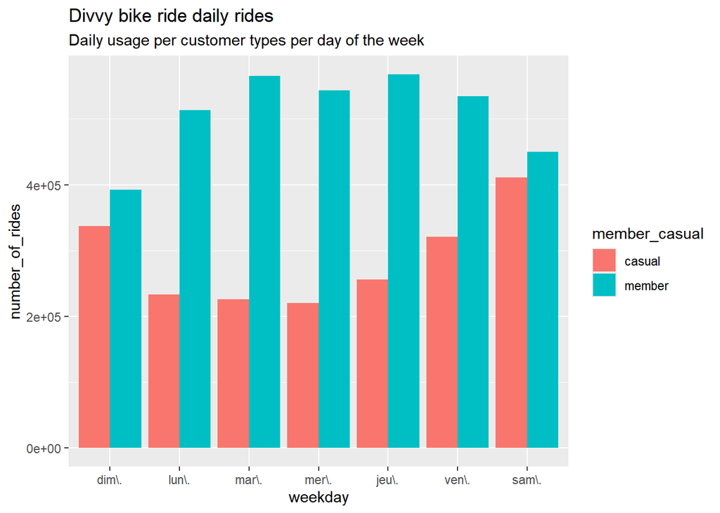

```r
# Let's visualize the number of rides by rider type
divvy_bike_trips_v3 %>%
  mutate(weekday = wday(started_at, label = TRUE)) %>%
  group_by(member_casual, weekday) %>%
  summarise(number_of_rides = n()
            ,average_duration = mean(ride_length)) %>%
  arrange(member_casual, weekday)  %>%
  ggplot(aes(x = weekday, y = number_of_rides, fill = member_casual)) +
  geom_col(position = "dodge") +
  labs(title="Divvy bike ride daily rides", subtitle="Daily usage per customer types per day of the week" )
```

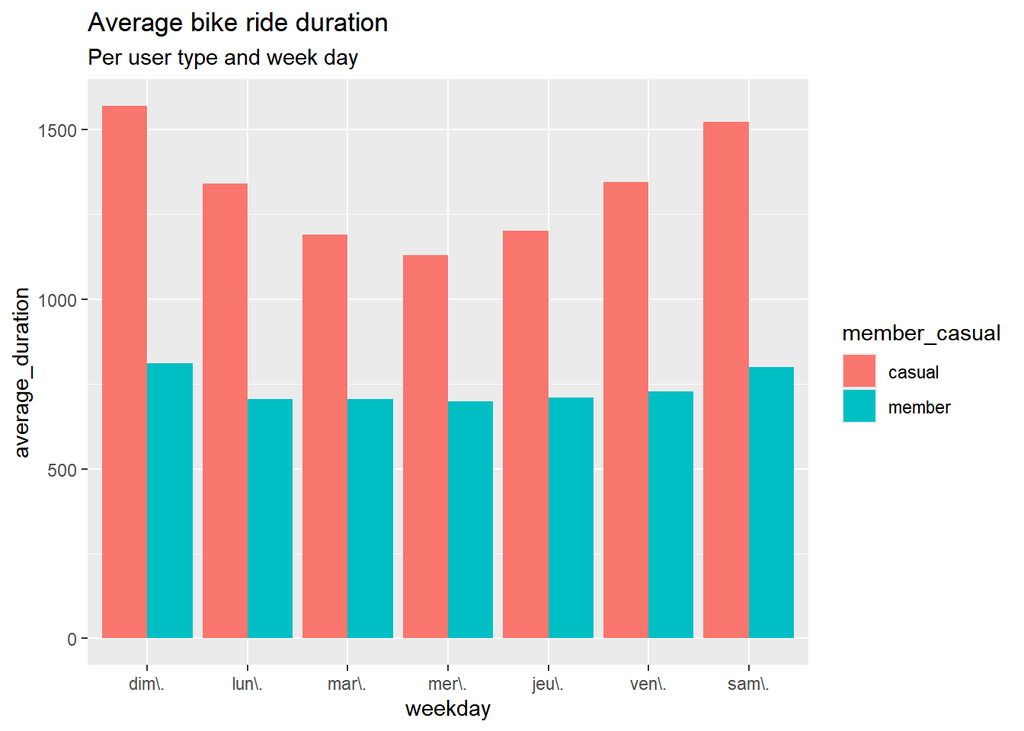

```r
# Let's create a visualization for average duration
divvy_bike_trips_v3 %>%
  mutate(weekday = wday(started_at, label = TRUE)) %>%
  group_by(member_casual, weekday) %>%
  summarise(number_of_rides = n()
            ,average_duration = mean(ride_length)) %>%
  arrange(member_casual, weekday)  %>%
  ggplot(aes(x = weekday, y = average_duration, fill = member_casual)) +
  geom_col(position = "dodge") +
  labs(title="Average bike ride duration", subtitle="Per user type and week day")
```

We created a summary of our findings and saved it as a new data frame

```r
#Summary of findings
counts <- aggregate(divvy_bike_trips_v3$ride_length ~ divvy_bike_trips_v3$member_casual + divvy_bike_trips_v3$day_of_week, FUN = mean)

#Visualizing our findings
View(counts)
```

### Export findings

```r
#Exporting our findings as a csv file
write.csv(counts, file = 'divvy_bike_trips_length.csv')
```

## VII.Conclusions

Our analysis of our historical data over a period of a year ranging from the month of november 2024 till october 2025, has shed the light on a few interesting facts about our customers us of our services.

Overall for our 2 customer types:

1.Casual riders